# Laboratorio di Programmazione Gr. 3 (N-Z)

# Corso di Laurea in Informatica

## Università degli Studi di Napoli Federico II

## A.A. 2021/22

# **I puntatori**

## Il concetto di **object**

> **object**: region of data storage in the execution environment, the contents of which can represent values

> (From: *C committee draft* www.open-std.org/jtc1/sc22/wg14/www/docs/n1256.pdf)

**NESSUNA** relazione con la *Programmazione ad Oggetti*

Quindi in *C*, una regione di memoria contenente dati è chiamata genericamente **object** (variabili, array, etc.)

`int answer = 42;`

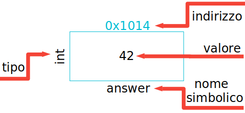

# I puntatori

Una variabile puntatore è una variabile in grado di contenere l' *indirizzo* di un object

`int* punt;` $\rightarrow$ dichiarazione di una variabile puntatore di nome `punt` di tipo *puntatore (`*`) a`int`*

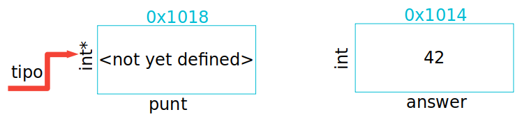

Tale variabile puntatore può contenere al suo interno un indirizzo di un object di tipo `int` ;

`punt = &answer;`$\rightarrow$ inserisce in `punt` l'indirizzo dell'object `answer`

l'operatore `&` significa *indirizzo di ...*

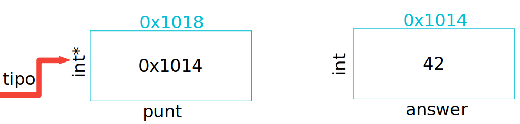

ovviamente potevo anche fare direttamente `int* punt = &answer;`

è possibile adesso riferirsi al *contenuto* dell'object `answer` attraverso `punt` utilizzando l'operatore `*`

```python
#include <stdio.h>
int main()
{
    int answer = 42;
    int* punt  = &answer;

    printf("answer:       %ld\n", answer);
    printf("punt (hex):   %p   dec: %ld\n", punt, punt);
    printf("*punt:  %ld\n", *punt);

    answer = answer + 10;

    printf("*punt:  %ld\n", *punt);

    *punt = *punt + 20;

    printf("*punt:  %ld\n", *punt);

    *punt = punt + 2;
    printf("*punt:  %ld\n", *punt);
    printf("answer: %ld\n", answer);
    return 0;
}
```

```
/tmp/tmp8i0l7x4t.c: In function ‘main’:
/tmp/tmp8i0l7x4t.c:19:11: warning: assignment to ‘int’ from ‘int *’ makes integer from pointer without a cast [-Wint-conversion]
   19 |     *punt = punt + 2;
      |           ^
```

```
answer:       42
punt (hex):   0x7fff74e7749c   dec: 140735154713756
*punt:  42
*punt:  52
*punt:  72
*punt:  1961325732
answer: 1961325732
```

## Attenzione all'operatore `*` (1)

Notiamo che l'operatore `*` può acquisire due significati differenti in base alla fase in cui si trova:

1. in fase di *dichiarazione* (**`int*`**`punt;` ): dichiara la variabile `punt` di tipo *puntatore a int*. In questa fase, l'operatore `*` è **sempre** preceduto dal tipo dell'object di cui il puntatore può contenere l'indirizzo (in questo caso `int`)
2. in fase di *deferenziazione* (e.g., `printf("%d",*punt)` o `int copy=*punt`): con`*` si desidera *accedere* al valore dell'object il cui indirizzo è contenuto nel puntatore `punt` (quindi già dichiarato in precedenza)

La posizione dell'operatore `*` in fase di dichiarazione è ininfluente, ossia:

`int* punt;` $\equiv$ `int * punt;` $\equiv$ `int *punt;`

`int* punt=&answer;` $\equiv$ `int * punt=&answer;` $\equiv$ `int *punt=&answer;`

**NB:** `int *punt=&answer;` significa *dichiara* *una variabile `punt` di tipo `int*`ed inserisci al suo interno l'indirizzo dell'object`answer`.*

Un altro modo di leggere `int *punt;` è il seguente: *dichiara una variabile di nome `punt` tale che la combinazione `*punt`sia un`int`.*

**`int`**`*punt=&answer;` $\not\equiv$ `*punt=&answer;`

Non fatevi ingannare dal `*` attaccato al nome dell'object! Ricordatevi che in questo caso siete in fase di **dichiarazione** (semplificando, quando alla sua sinistra c'è un tipo).

## Attenzione all'operatore `*` (2)

Nei testi la sintassi più utilizzata per la dichiarazione di un puntatore è `tipo *nome`, e.g. `int *punt;` invece che `int* punt;`. L'utilizzo della sintassi `tipo *nome` permette di evitare ambiguità in caso di dichiarazioni multiple.

Esempio:

`int* p,q;` dichiara la variabile `p` di tipo *puntatore a* `int`, mentre la variabile `q` sarà di tipo `int` ma **non** puntatore (in sostanza, l'operatore `*` viene applicato solo al primo object, e non agli altri).

Per avere entrambe le variabili di tipo puntatore a int: `int* p,*q;`, oppure `int * p, * q;`, oppure...

```
    int* p;
    int* q;
```

## Attenzione all'operatore `&`

Potreste trovare del codice con istruzioni del tipo:

**`int&`**`r = q;` oppure **`int &`**`r = q;` oppure **`int&`**`r = q;`

Se trovate una istruzione del genere, allora non state avendo a che fare con il linguaggio *C*, ma con in linguaggio *C++*.

In *C++* l'operatore `&`, se posto di fianco ad un tipo in fase di dichiarazione non è più operatore *indirizzo*, ma di *aliasing*.

L' *aliasing* non esiste in *C*! E' una caratteristica del *C++*, e come tale non oggetto di questo corso!

## Buone norme di puntamento

In C, la dichiarazione di un puntatore non gli assegna automaticamente un valore!

$\rightarrow$Evitare di dichiarare puntatori senza inizializzarli!

`int* p;`

In tal caso `p`, se allocato nel call stack, potrebbe contenere al suo interno qualsiasi valore. Una sua eventuale deferenziazione `*p = ...` per assegnargli un valore può essere pericolosa (si pensi se casualmente `p` contenesse l'indirizzo di memoria di una object `const`...). Generalmente, molti bugs nascono da una cattiva/mancata inizializzazione dei puntatori.

Se non si conosce ancora quale sarà l'object a cui dovrà puntare `p` o non è stato ancora dichiarato, meglio inizializzarlo con `NULL`. `NULL` è una macro definita nell' header `stdio.h` corrispondente all'indirizzo `0`.

`int* p = NULL;`

In `C` è garantito che nessun object esiste né esisterà all'indirizzo `NULL`. Attraverso questa convenzione, è possibile controllare se un puntatore punta o meno ad un oggetto (e.g., `if(p == NULL){...}`).

Ciò non toglie che deferenziare un puntatore che (non) punta a null(a) è concettualmente sbagliato, anche se sintatticamente corretto

```
int* p = 0;
*p     = 10; //sbagliato! ma nessun errore da parte del compilatore
```

```python
#include <stdio.h>
int main()
{
    int *p;
    printf("puntatore p non inizializzato. Valore:%p\n", p);

    int *q = NULL;
    printf("puntatore q inizializzato. Valore:%p, corrispondente al decimale: %lld \n", q, q);

    return  0;
}
```

puntatore p non inizializzato. Valore:0x7ffe4419bf40

puntatore q inizializzato. Valore:(nil), corrispondente al decimale: 0

## C arrays OF pointers

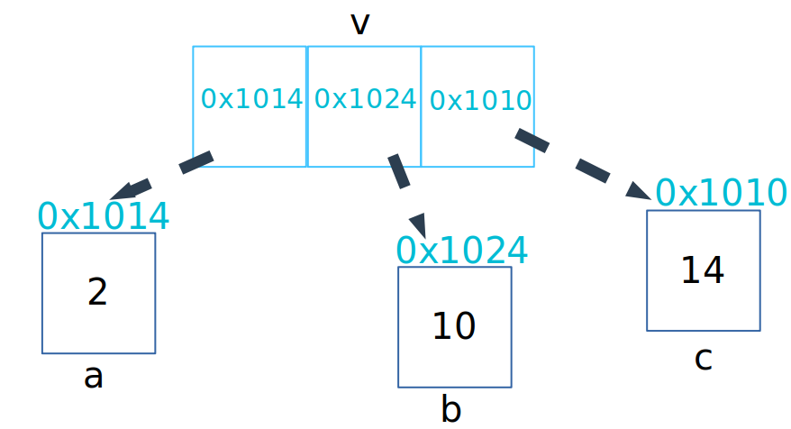

```python
#include <stdio.h>
int main()
{
    int* v[3];
    int a = 2;
    int b = 10;
    int c = 14;
    v[0] = &a;
    v[1] = &b;
    v[2] = &c;
    printf("Prima:\n");
    printf("a:     %d, b:     %d, c:    %d\n", a,b,c);
    printf("*v[0]: %d, *v[1]: %d, *v[2]:%d\n", *v[0],*v[1],*v[2]);

    a++;
    b = b + 2;
    c = a + b;
    printf("dopo:\n");

    printf("*v[0]: %d, *v[1]: %d, *v[2]:%d\n", *v[0],*v[1],*v[2]);



    return 0;
}
```

```
Prima:
a:     2, b:     10, c:    14
*v[0]: 2, *v[1]: 10, *v[2]:14
dopo:
*v[0]: 3, *v[1]: 12, *v[2]:15
```

## C arrays AS pointers (?)

> Except when it is the operand of the sizeof operator or the unary & operator, or is a string literal used to initialize an array, an expression that has type ‘‘array of type’’ is converted to an expression with type ‘‘pointer to type’’ that points to the initial element of the array object and is not an lvalue. If the array object has register storage class, the behavior is undefined. (C standard, http://www.open-std.org/jtc1/sc22/wg14/www/docs/n1256.pdf)

Il *nome* di un array può essere utilizzato, *nella maggioranza delle volte*, *come se fosse* un puntatore costante (ossia il cui indirizzo memorizzato non può essere modificato). Tale *"puntatore"* punta al primo elemento di un array

```python
#include <stdio.h>
int main()
{
    int v[3] = {3, 10, 42};
    printf("primo valore del vettore v visto come array: %d\n", v[0]);
    printf("primo valore del vettore v visto come puntatore: %d\n", *v);
    printf("indirizzo usando v: %p; indirizzo usando &v[0]: %p\n", v, &v[0]);
    return 0;
}
```

```
primo valore del vettore v visto come array: 3
primo valore del vettore v visto come puntatore: 3
indirizzo usando v: 0x7ffe03a79e2c; indirizzo usando &v[0]: 0x7ffe03a79e2c
```

Una delle eccezioni è l'operatore `sizeof` che ha comportamenti differenti

```python
#include <stdio.h>
int main()
{
    int v[] = {3, 10, 42};
    int *p_v = v;

    printf("v: %p; p_v: %p; &v: %p; p_v: %p\n", v, p_v, &v, &p_v);
    printf("sizeof(v): %d Byte\n", sizeof(v));
    printf("sizeof(p_v): %d Byte\n", sizeof(p_v));
    return 0;
}
```

```
v: 0x7ffed829286c; p_v: 0x7ffed829286c; &v: 0x7ffed829286c; p_v: 0x7ffed8292860
sizeof(v): 12 Byte
sizeof(p_v): 8 Byte
```

pur puntando allo stesso vettore, l'operatore `sizeof` applicato al *nome* di un array restituisce la dimensione effettiva dell'array, mentre se applicato ad un puntatore che punta ad un array restituisce la dimensione del puntatore.

Questo implica che un array non è mai copiato quando passato come argomento di una funzione, mentre ciò che viene materialmente passato è il solo indirizzo al suo primo elemento.

Se però un array viene passato come parametro ad una funzione, l'array viene trattato esattamente come un puntatore, *indipendentemente se questo è passato come array o come puntatore*.

> There is one difference between an array name and a pointer that must be kept in mind. A pointer is a variable, so pa=a and pa++ are legal. But an array name is not a variable; constructions like a=pa and a++ are illegal. (from: Expert C Programming)

```python
#include <stdio.h>
void f(int f_v[]) // equivalente a void f(int* f_v)
{
    printf("sizeof(f_v): %d Byte\n", sizeof(f_v));

}

int main()
{
    int v[] = {3, 10, 42};
    int *p_v = v;
    printf("sizeof(v):   %d Byte\n", sizeof(v));
    printf("sizeof(p_v): %d Byte\n", sizeof(p_v));
    f(v);
    return 0;
}
```

```
/tmp/tmpexfqqp0b.c: In function ‘f’:
/tmp/tmpexfqqp0b.c:4:44: warning: ‘sizeof’ on array function parameter ‘f_v’ will return size of ‘int *’ [-Wsizeof-array-argument]
    4 |     printf("sizeof(f_v): %d Byte\n", sizeof(f_v));
      |                                            ^
/tmp/tmpexfqqp0b.c:2:12: note: declared here
    2 | void f(int f_v[]) // equivalente a void f(int* f_v)
      |        ~~~~^~~~~
```

```
sizeof(v):   12 Byte
sizeof(p_v): 8 Byte
sizeof(f_v): 8 Byte
```

## Pointers to pointers

```
int answer     = 42;
int* punt      = &answer;
int** puntpunt = &punt;
```

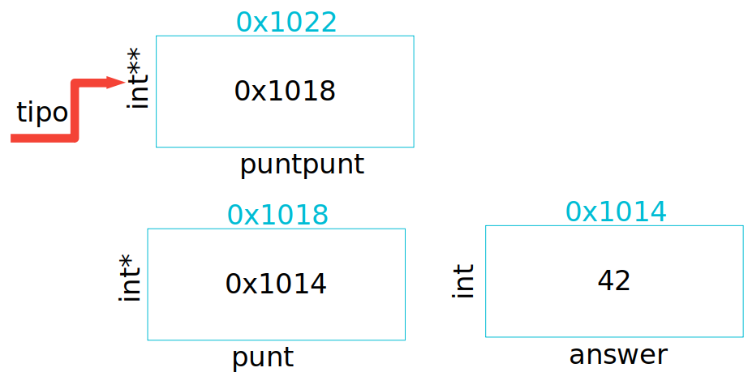

```python
#include <stdio.h>
int main()
{
    int answer      = 42;
    int* punt       = &answer;
    int** puntpunt  = &punt;
    printf("answer:        %d\n", answer);
    printf("&answer(hex):  %p\n", &answer);
    printf("=======================\n");
    printf("punt:          %p\n", punt);
    printf("*punt:         %d\n", *punt);
    printf("&punt(hex):    %p\n", &punt);
    printf("=======================\n");
    printf("puntpunt:      %p\n", puntpunt);
    printf("*puntpunt:     %p\n", *puntpunt);
    printf("**puntpunt:    %d\n", **puntpunt);
    printf("&puntpunt(hex):%p\n", &puntpunt);

    return 0;

}
```

```
answer:        42
&answer(hex):  0x7fffc79a7424
=======================
punt:          0x7fffc79a7424
*punt:         42
&punt(hex):    0x7fffc79a7428
=======================
puntpunt:      0x7fffc79a7428
*puntpunt:     0x7fffc79a7424
**puntpunt:    42
&puntpunt(hex):0x7fffc79a7430
```

### I nomi delle matrici **non** allocate dinamicamente possono essere visti come puntatore a puntatore?

**NO!**

In generale, un array multidimensionale è visto come un puntatore *a elementi di tipo array*.

`int (*) [ ]` $\not \equiv$ `int**`

i puntatori a elementi di tipo array non saranno argomento di questo corso.

```python
#include <stdio.h>
int main()
{
    int M[2][3] = {
                   {3, 10, 42},
                   {4, 11, 94}
                  };
    printf("primo valore della matrice M vista come array: %d\n", M[0][0]);
    printf("primo valore della matrice M vista come puntatore: %d\n", (*M)[0]);
    printf("indirizzo usando M: %p; indirizzo usando &M[0]: %p\n", M, &M[0]);
    int** p_M = M;
    printf("primo valore della matrice M usando un puntatore a puntatore: %d\n", **p_M);
    return 0;
}
```

```
/tmp/tmp11spqkk8.c: In function ‘main’:
/tmp/tmp11spqkk8.c:11:17: warning: initialization of ‘int **’ from incompatible pointer type ‘int (*)[3]’ [-Wincompatible-pointer-types]
   11 |     int** p_M = M;
      |                 ^
```

```
primo valore della matrice M vista come array: 3
primo valore della matrice M vista come puntatore: 3
indirizzo usando M: 0x7ffc2f49bfc0; indirizzo usando &M[0]: 0x7ffc2f49bfc0
```

```
[C kernel] Executable exited with code -11
```

# Puntatori di tipo `void`

Un puntatore di tipo `void` (ossia `void*`) può contenere l'indirizzo di un object di qualsiasi tipo

```
void* p;
int a = 3;
p     = &a;
```

nessun problema in fase si compilazione. Ma...

```python
#include <stdio.h>

int main()
{
 void* p;
 int a = 3;
 p     = &a;
 printf("%d", *p);

 return 0;
}
```

```
/tmp/tmpkrasiz3x.c: In function ‘main’:
/tmp/tmpkrasiz3x.c:8:15: warning: dereferencing ‘void *’ pointer
    8 |  printf("%d", *p);
      |               ^~
/tmp/tmpkrasiz3x.c:8:15: error: invalid use of void expression
[C kernel] GCC exited with code 1, the executable will not be executed
```

La derefenziazione di un puntatore `void` in generale non ha senso.

Il compilatore deve sapere *di che tipo è* la memoria a cui sta accedendo, così da poterla trattare nella maniera corretta (e.g. il valore da gestire da quanti byte è composto? devo considerarlo con segno o no? ecc.)

```python
#include <stdio.h>
// esempio di casting
int main()
{
 void* p;
 int a = 3;
 p     = &a;
 printf("%d",*((int*)p));

 return 0;
}
```

```
3
```

```python
// Conversioni tra puntatori
#include <stdio.h>
int main()
{
  int x = 587;
  char* p;
  p = (char*) &x; // casting a tipo diverso
  printf("The (incorrect) value of x is: %d\n", *p);
  printf("size of int: %d, size of char: %d\n", sizeof(int), sizeof(char));
  printf("correct   x value: (dec): %d (hex): %X\n", x,x);
  printf("incorrect x value: (dec): %d  (hex): %X\n",*p, *p);
  return 0;
}
```

```
The (incorrect) value of x is: 75
size of int: 4, size of char: 1
correct   x value: (dec): 587 (hex): 24B
incorrect x value: (dec): 75  (hex): 4B
```

Dato che `p` è dichiarato come puntatore a `char`, solo $1$ byte del dato effettivo viene preso in considerazione invece dei $4$ byte che compongono una variabile di tipo byte

## Puntatori a strutture

```
#include <stdio.h>
#define MAX_PAZIENTI 3
struct Paziente
{
    float altezza;
    float peso;
    int   eta;
};

int main()
{
    struct Paziente paz;
    struct Paziente* p_s;
    p_s = &paz;

    (*p_s).altezza = 1.70; //oppure p_s->altezza = 1.70;

}
```

#### Operatore `->`

data che l'operazione di accesso ai membri di una struttura puntata è più frequente di quanto si pensi, il C introduce l'operatore `->`.

Data una struct allocata con nome `S` ed avente un campo `B`, e dato un puntatore `A` contenente l'indirizzo di `S`, i.e., `A=&S;`, allora:

`A->B` $\equiv$ `(*A).B`

#### Array di puntatori a strutture

```
#include <stdio.h>
#define MAX_PAZIENTI 3
struct Paziente
{
    float altezza;
    float peso;
    int   eta;
};

int main()
{

    struct Paziente* V_p[MAX_PAZIENTI];
    struct Paziente pa,pb,pc;
    V_p[0] = &pa;
    V_p[1] = &pb;
    V_p[2] = &pc;
    for(int i=0;  i < MAX_PAZIENTI; i=i+1)
    {
        printf("inserisci l'altezza del %d paziente: ", i+1);
        scanf("%d", &(*V_p[i]).altezza);
        printf("inserisci il peso del %d paziente: ", i+1);
        scanf("%d", &V_p[i]->peso)
        printf("inserisci l'età del %d paziente: ", i+1);
        scanf("%d", &V_p[i]->eta)
    }

    return 0;
}
```

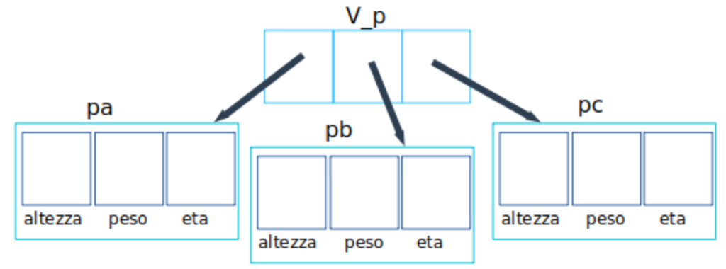

Ovviamente in questo caso specifico gli array di puntatori non sono né utili né convenienti...ma nel caso di allocazione dinamica delle strutture sì (vedremo poi)

```python
#include <stdio.h>
struct Paziente
{
    float altezza;
    float peso;
    int   eta;
};

int main()
{
    const int n = 3;
    struct Paziente* V_p[n];
    struct Paziente pa,pb,pc;
    V_p[0] = &pa;
    V_p[1] = &pb;
    V_p[2] = &pc;
    printf("dimensione del diario pazienti (solo vettore): %d Byte\n", sizeof(V_p));
    printf("dimensione di ogni puntatore: %d\n", sizeof(struct Paziente*));
    printf("dimensione di ogni struttura: %d\n", sizeof(struct Paziente));
    return 0;
}
```

[output not shown]